# EDA

## Arrival Delay by Month

```r
df_2013 %>%
  group_by(month) %>%
  summarise(mean_ad = mean(arr_delay), sd_ad = sd(arr_delay), IQR_ad = IQR(arr_delay), n = n()) %>%
  arrange(desc(mean_ad))
```

```
## # A tibble: 12 × 5
##    month mean_ad sd_ad IQR_ad     n
##    <fct>   <dbl> <dbl>  <dbl> <int>
##  1 Jul     17.3   58.8   43    4053
##  2 Jun     16.1   53.6   40    6465
##  3 Apr     14.3   48.4   35    8496
##  4 Dec      9.89  37.4   27.2  3828
##  5 Jan      9.12  40.9   30    6417
##  6 Aug      7.60  38.5   31    3726
##  7 Mar      5.20  40.5   29   10399
##  8 Feb      3.56  36.8   27    6925
##  9 May      2.32  42.5   30    5228
## 10 Nov      2.31  31.0   25    8202
## 11 Oct      1.27  33.7   24    4812
## 12 Sep     -1.56  35.6   25    4183
```

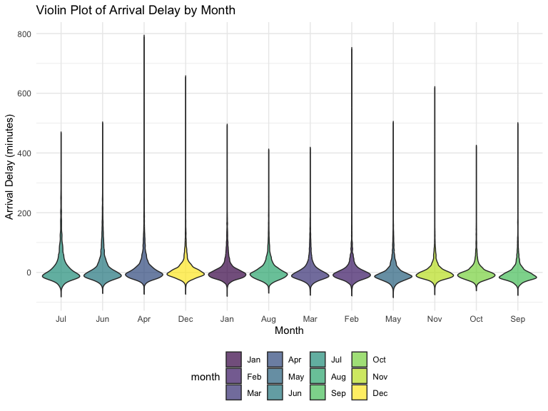

```r
# Plot violin plot of arr_delay against month, coloring by month
# reversing the order from high to low
delay_month_box =
  ggplot(df_2013, aes(x = reorder(month, -arr_delay), y = arr_delay, fill = month)) +
  geom_violin(trim = FALSE, scale = "width", alpha = 0.7) +
  labs(title = "Violin Plot of Arrival Delay by Month",
       x = "Month",
       y = "Arrival Delay (minutes)")

delay_month_box
```

## Tailnum

```r
flights_delay <-
  df_2013 %>%
  group_by(tailnum) %>%
  summarize(
    count = n(),
    avg_delay = mean(arr_delay)
  )
```

```r
flights_delay
```

```
## # A tibble: 3,737 × 3
##    tailnum count avg_delay
##    <chr>   <int>     <dbl>
##  1 D942DN      2     16.5
##  2 N0EGMQ     79     12.4
##  3 N10156     39      7.56
##  4 N102UW      8     27.8
##  5 N103US      7     -5.86
##  6 N104UW      3    -19.7
##  7 N10575     75     26.0
##  8 N105UW     12     -9.08
##  9 N107US      7     12.9
## 10 N108UW     11      7.82
## # ℹ 3,727 more rows
```

[output not shown]

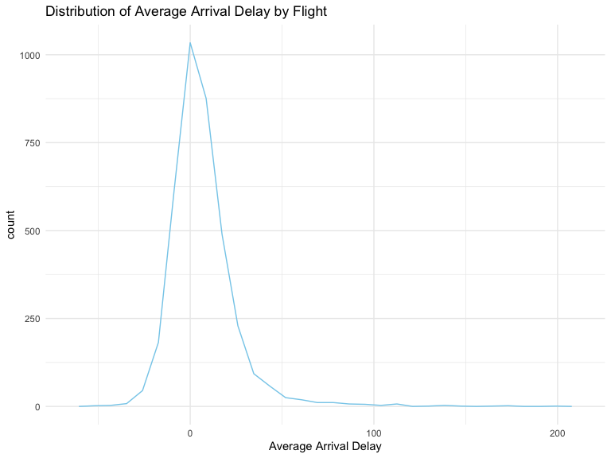

```r
ggplot(flights_delay, aes(avg_delay)) +
  geom_freqpoly(color = 'skyblue') +
  labs(title = "Distribution of Average Arrival Delay by Flight",
       x = "Average Arrival Delay"
       )
```

```r
max_delay <-
  flights_delay %>%
  arrange(-avg_delay)

max_delay
```

```
## # A tibble: 3,737 × 3
##    tailnum count avg_delay
##    <chr>   <int>     <dbl>
##  1 N305AS      1      196
##  2 N933LR      2      176.
##  3 N621SW      1      175
##  4 N635AA      5      161.
##  5 N136DL      1      146
##  6 N610WN      1      141
##  7 N540US      2      140.
##  8 N299AT      1      139
##  9 N938LR      1      128
## 10 N354AT      3      116.
## # ℹ 3,727 more rows
```

N305AS had an average delay of 196 minutes, which is about 3 hours.

## On time arrival rate for NYC airports

Suppose a flight that is delayed for less than 5 minutes is basically “on time”. Assume we onsider any flight delayed for 5 minutes of more to be “delayed”

```r
df_2013 <-
  df_2013 %>%
  mutate(
    ontime = arr_delay < 5
    )

df_2013 <-
  df_2013 %>%
  mutate(
    arr_type = ifelse(arr_delay < 5, "on time", "delayed")
    )

df_2013 %>%
  group_by(origin) %>%
  summarise(ontime_prop = sum(ontime == TRUE) / n()) %>%
  arrange(desc(ontime_prop))
```

```
## # A tibble: 3 × 2
##   origin ontime_prop
##   <chr>        <dbl>
## 1 LGA          0.661
## 2 JFK          0.636
## 3 EWR          0.625
```

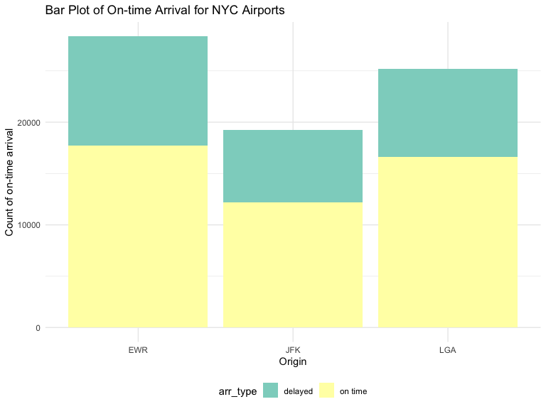

```r
ggplot(data = df_2013, aes(x = origin, fill = arr_type)) +
  geom_bar()+
  scale_fill_brewer(palette = "Set3") +
  labs(title = "Bar Plot of On-time Arrival for NYC Airports",
       x = "Origin",
       y = "Count of on-time arrival")
```

The plot shows that LGA airport has the best on time arrival rate and EWR airport has the worst.

## Average Speed for flight (air_time & distance)

We set average speed = distance / (air_time/60) in miles/hr.

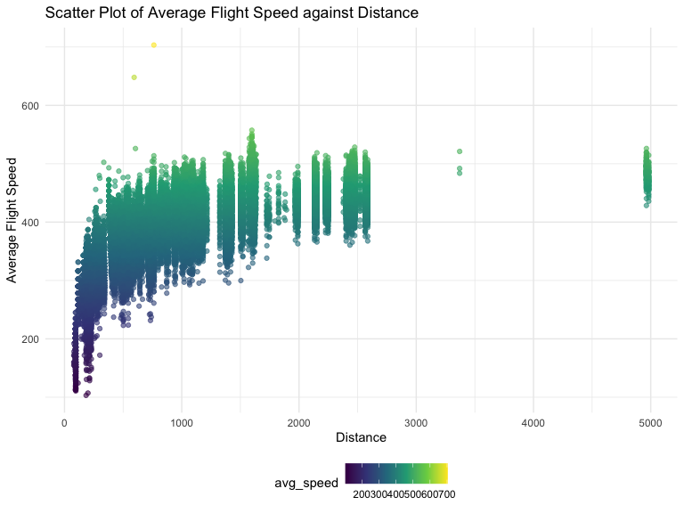

```r
df_2013 <-
  df_2013 %>%
  mutate(
    avg_speed = distance / (air_time/60)
    )

ggplot(data = df_2013, aes(x = distance, y = avg_speed, color = avg_speed)) +
  geom_point(alpha = .6) +
  scale_fill_brewer(palette = "Set3") +
  labs(title = "Scatter Plot of Average Flight Speed against Distance",
       x = "Distance",
       y = "Average Flight Speed")
```

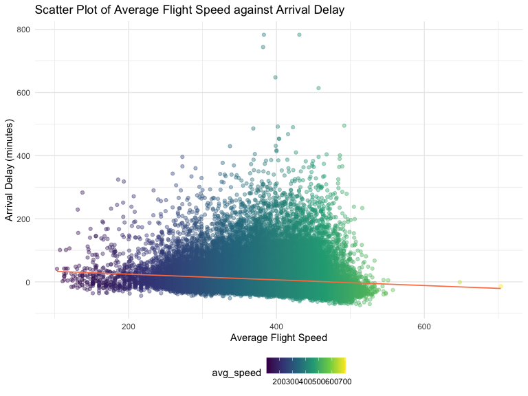

```r
ggplot(data = df_2013, aes(x = avg_speed, y = arr_delay, color = avg_speed)) +
  geom_point(alpha = .4) +
  scale_fill_brewer(palette = "Set3") +
  geom_smooth(method = "lm", se = FALSE, color = "coral", size = 0.6) +
  labs(title = "Scatter Plot of Average Flight Speed against Arrival Delay",
       x = "Average Flight Speed",
       y = "Arrival Delay (minutes)")
```